# monte_carlo_simulate_correlated_inputs

### Simulation and distributions

In order to understand how the correlation between the inputs impacts the standard error on the regression coefficients, we need to find some data! Although we could find *real* data to work with, we can also *simulate* data! This way we are in control of the assumptions and we will know everything there is to know about the data.

Let's start out with a simple case where the inputs are **not** correlated. We will assume that both inputs have marginal standard normal distributions. Thus, they each have mean equal to 0 and standard deviation equal to 1. We can generate random values for the inputs by calling a Gaussian random number generator. However, we want to expand our example to a setting where the inputs are correlated. Thus, we will work with the more general multivariate normal (MVN) distribution. The MVN is a distribution that describes the central tendancy of a collection of variables, their uncertainty, and how they relate to each other or their *covariance*. The general notation for the MVN for $D$ variables, $\mathbf{x}=x_1, x_2, ..., x_d, ..., x_D$:

$$\mathbf{x} \mid \boldsymbol{\mu}, \boldsymbol{\Sigma} \sim \mathrm{multivariate \, normal} \left(\mathbf{x} \mid \boldsymbol{\mu}, \boldsymbol{\Sigma}\right) $$

In the above expression, $\boldsymbol{\mu}$ is the mean vector, and $\boldsymbol{\Sigma}$ is the covariance matrix. Let's focus on our specific case where we have 2 inputs, thus our mean vector will be $(2\times1)$ and our covariance matrix will be $(2\times2)$.

$$\begin{bmatrix} x_1 \\ x_2 \end{bmatrix} \sim \mathrm{multivariate \, normal} \left( \begin{bmatrix} \mu_1 \\ \mu_2 \end{bmatrix} , \begin{bmatrix} \mathrm{var}(x_1) & \mathrm{cov}(x_1, x_2) \\ \mathrm{cov}(x_2, x_1) & \mathrm{var}(x_2) \end{bmatrix} \right)$$

The MVN can be simplified by writing the covariance in terms of the marginal standard deviations for each input $\sigma_1$, $\sigma_2$ and the correlation coefficient, $\rho$, between them:

$$\begin{bmatrix} x_1 \\ x_2 \end{bmatrix} \sim \mathrm{multivariate \, normal} \left( \begin{bmatrix} \mu_1 \\ \mu_2 \end{bmatrix} , \begin{bmatrix} \sigma_1^2 & \rho \sigma_1 \sigma_2 \\ \rho \sigma_1 \sigma_2 & \sigma_2^2 \end{bmatrix} \right)$$

By assuming each input has a *marginal* standard normal distribution, each input has means of 0, $\mu_1 =\mu_2 = 0$, and standard deviations equal to 1, $\sigma_1 = \sigma_2 = 1$. The MVN distribution simplifies considerably:

$$\begin{bmatrix} x_1 \\ x_2 \end{bmatrix} \sim \mathrm{multivariate \, normal} \left( \begin{bmatrix} 0 \\ 0 \end{bmatrix} , \begin{bmatrix} 1 & \rho \\ \rho & 1 \end{bmatrix} \right)$$

Now, when we consider our starting case of **uncorrelated** inputs, the correlation coefficient is equal to 0, $\rho = 0$. The multivariate normal has simplified even further, the covariance matrix is just the identity matrix:

$$\begin{bmatrix} x_1 \\ x_2 \end{bmatrix} \sim \mathrm{multivariate \, normal} \left( \begin{bmatrix} 0 \\ 0 \end{bmatrix} , \begin{bmatrix} 1 & 0 \\ 0 & 1 \end{bmatrix} \right)$$

The above distribution is equivalent to two independent standard normals:

$$x_1 \sim \mathrm{normal}\left(x_1 \mid 0, 1 \right)$$

$$x_2 \sim \mathrm{normla}\left(x_2 \mid 0, 1 \right)$$

Again we are working with the general multivariate case so it is easier to expand to correlated inputs later.

Now that we know what distribution to use, it's time to generate random observations! Let's follow the same approach we used at the start of the semester where we import the necessary modules then initialize the NumPy random number generator object.

```python
import numpy as np
import pandas as pd
import matplotlib.pyplot as plt

import seaborn as sns
```

```python
rg = np.random.default_rng( 2120 )
```

Before calling the random number generator, we need to specify the mean vector and covariance matrix. With marginal standard normals and uncorrelated inputs, the mean is a vector of 0s and the covariance matrix is the identity matrix.

```python
num_inputs = 2

mean_vector = np.zeros( num_inputs )

cov_matrix_rho_zero = np.identity( num_inputs )
```

The mean vector is printed below.

```python
print ( mean_vector )
```

```
[0. 0.]
```

The covariance matrix is displayed below.

```python
cov_matrix_rho_zero
```

```
array([[1., 0.],
       [0., 1.]])
```

Let's now generate 100 observations from our multivariate normal.

```python
xinputs_rho_zero_mat = rg.multivariate_normal(mean_vector, cov_matrix_rho_zero, size=100)
```

```python
print( type(xinputs_rho_zero_mat) )

print( xinputs_rho_zero_mat.shape )
```

```
<class 'numpy.ndarray'>
(100, 2)
```

Convert the NumPy ndarray into a DataFrame to make plotting easier with Seaborn.

```python
xinputs_rho_zero_df = pd.DataFrame(xinputs_rho_zero_mat, columns=['x'+str(d+1).zfill(2) for d in range(num_inputs)])
```

```python
xinputs_rho_zero_df
```

|  | x01 | x02 |
| --- | --- | --- |
| 0 | 0.845719 | -1.397593 |
| 1 | -0.548308 | 0.951682 |
| 2 | -1.055123 | 0.745590 |
| 3 | 0.538391 | -1.197280 |
| 4 | -0.506405 | -0.904358 |
| ... | ... | ... |
| 95 | 0.721628 | 0.332253 |
| 96 | 0.509029 | 0.154173 |
| 97 | 0.055094 | 0.206093 |
| 98 | 0.877001 | -0.095699 |
| 99 | -0.143166 | 1.014641 |

100 rows × 2 columns

Let's visualize the scatter plot, a kernel density estimate for the marginal distribution, and the joint density estimate with Seaborn. The inputs are uncorrelated and so we do not see any direction in the scatter plot!

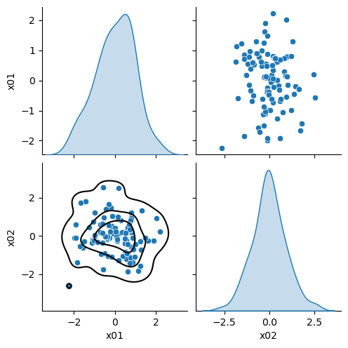

```python
g = sns.pairplot(data = xinputs_rho_zero_df, diag_kind='kde')
g.map_lower(sns.kdeplot, levels = 4, color='black')

plt.show()
```

### Regression coefficient calculations

Great! We just generated our inputs! How can calculate standard errors on the coefficients of our linear model? We do not have any responses!

The covariance matrix of the $\boldsymbol{\beta}$ parameters is only influenced by the response, $\mathbf{y}$, via the residual error, $\hat{\sigma}$. The covariance structure is completely determined by the covariance structure of the inputs! Thus, we can completely study the uncertainty and relationship between the parameters without having any values for the response!

We need to organize the inputs properly though to support our calculations. We must create the design matrix, $\mathbf{X}$. The design matrix will depend on our model formulation, our desired set of features. For our current application, we are working with linear additive features:

$$\mu_n = \beta_0 + \beta_1 x_{n,1} + \beta_2 x_{n,2}$$

Let's use `dmatrix()` to create the design matrix for us. The `dmatrix()` function is the sister function to `dmatrices()`. The `dmatrix()` function only generates the design matrix or input feature array. It does not generate the output array.

```python
from patsy import dmatrix
```

```python
X_rho_zero = dmatrix( ' ~ x01 + x02', data = xinputs_rho_zero_df)
```

```python
print( type(X_rho_zero) )

print( X_rho_zero.shape )
```

```
<class 'patsy.design_info.DesignMatrix'>
(100, 3)
```

Looking at the head of our design matrix shows the "intercept column of 1's"!

```python
pd.DataFrame(X_rho_zero).head()
```

|  | 0 | 1 | 2 |
| --- | --- | --- | --- |
| 0 | 1.0 | 0.845719 | -1.397593 |
| 1 | 1.0 | -0.548308 | 0.951682 |
| 2 | 1.0 | -1.055123 | 0.745590 |
| 3 | 1.0 | 0.538391 | -1.197280 |
| 4 | 1.0 | -0.506405 | -0.904358 |

Let's now calculate the matrix sum of squares using our randomly generated input values. The number of rows and columns of the matrix sum of squares is equal to the number of columns in the design matrix! Several linear algebra related functions are required to execute the calculations. The cell below uses the `np.dot()` function and the `.T` attribute to matrix multiply the transpose of the design matrix with itself.

```python
SSmat_rho_zero = np.dot( X_rho_zero.T, X_rho_zero )
```

```python
print( SSmat_rho_zero )
```

```
[[100.          -0.15922493  -1.67926222]
 [ -0.15922493  88.93157023  -5.17180241]
 [ -1.67926222  -5.17180241  83.98430012]]
```

The scaled covariance matrix between the $\boldsymbol{\beta}$ parameter is then the inverse of the matrix sum of squares. We will refer to this as the *scaled* covariance matrix, because we are essentially ignoring the residual error. Large values of the residual error will *increase* the standard error of the coefficients even further. The `np.linalg.inv()` function is used to invert the matrix sum of squares below.

```python
beta_cov_rho_zero = np.linalg.inv( SSmat_rho_zero )
```

```python
print( beta_cov_rho_zero )
```

```
[[1.00034367e-02 2.96485713e-05 2.01844033e-04]
 [2.96485713e-05 1.12851026e-02 6.95536053e-04]
 [2.01844033e-04 6.95536053e-04 1.19538547e-02]]
```

The standard errors of three $\beta$ parameters are the square root of the terms along the main diagonal.

```python
np.sqrt( np.diag( beta_cov_rho_zero) )
```

```
array([0.10001718, 0.10623136, 0.10933369])
```

### Repeat with highly positively correlated inputs

Let's repeat the above calculations but this time using highly positively correlated inputs. We will generate 100 random observations of 2 inputs with marginal standard normals, but with $\rho = 0.9$. The multivariate normal distribution is now:

$$\begin{bmatrix} x_1 \\ x_2 \end{bmatrix} \sim \mathrm{multivariate \, normal} \left( \begin{bmatrix} 0 \\ 0 \end{bmatrix} , \begin{bmatrix} 1 & 0.9 \\ 0.9 & 1 \end{bmatrix} \right)$$

The cell below defines the new covariance matrix by creating the $(2\times2)$ array manually.

```python
cov_matrix_rho_high = np.array([[1, 0.9], [0.9, 1]])

print( cov_matrix_rho_high )
```

```
[[1.  0.9]
 [0.9 1. ]]
```

100 random observations are generated below using the same function call as before, but with the new covariance matrix. The NumPy array is converted to a DataFrame afterwards to support plotting.

```python
xinputs_rho_high_mat = rg.multivariate_normal(mean_vector, cov_matrix_rho_high, size=100)
```

```python
xinputs_rho_high_df = pd.DataFrame(xinputs_rho_high_mat, columns=['x'+str(d+1).zfill(2) for d in range(xinputs_rho_high_mat.shape[1])])
```

Visualizing the marginal distributions, scatter plot, and joint distribution reveals that *marginally* each input behaves as a standard normal! However, we clearly have a different scatter plot than our previous one! The observations fall tightly along the diagonal. As `x01` increases so does `x02`. A linear relationship exists between the two inputs!

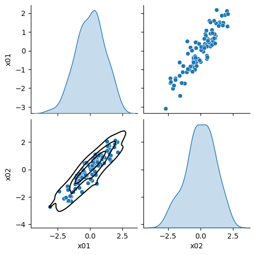

```python
g = sns.pairplot(data = xinputs_rho_high_df, diag_kind='kde')
g.map_lower(sns.kdeplot, levels = 4, color='black')

plt.show()
```

Let's now repeat the calculation of the regression coefficient covariance matrix.

```python
X_rho_high = dmatrix( ' ~ x01 + x02', data = xinputs_rho_high_df)

SSmat_rho_high = np.dot( X_rho_high.T, X_rho_high )

beta_cov_rho_high = np.linalg.inv( SSmat_rho_high )
```

The covariance matrix calculated from the randomly generated highly positively correlated inputs is shown below.

```python
print( beta_cov_rho_high )
```

```
[[ 0.01003956 -0.00139741  0.00126057]
 [-0.00139741  0.04943662 -0.04380282]
 [ 0.00126057 -0.04380282  0.04710202]]
```

The *scaled* standard error on the coefficients is printed below.

```python
print( np.sqrt( np.diag( beta_cov_rho_high) ) )
```

```
[0.10019761 0.22234347 0.21703   ]
```

How does this compare to what we had with the uncorrelated inputs? Let's put the results into a DataFrame so it's a little easier to display.

```python
pd.DataFrame({'uncorrelated': np.sqrt( np.diag(beta_cov_rho_zero) ),
              'high positive correlation': np.sqrt( np.diag(beta_cov_rho_high))},
            index=['SE beta_0', 'SE beta_1', 'SE beta_2'])
```

|  | uncorrelated | high positive correlation |
| --- | --- | --- |
| SE beta_0 | 0.100017 | 0.100198 |
| SE beta_1 | 0.106231 | 0.222343 |
| SE beta_2 | 0.109334 | 0.217030 |

The standard errors on the slopes $\beta_1$ and $\beta_2$ have essentially doubled! The potential impact of this is that the highly correlated inputs have made it more difficult to know if one of the two inputs is statistically significant or not!

Let's check the correlation coefficient between $\beta_1$ and $\beta_2$. The definition for the correlation coefficient is:

$$\rho = \frac{\mathrm{cov}\left(x_1, x_2\right)}{\sigma_1 \sigma_2} $$

Let's define a function to help us calculate it. The first argument to `calc_cor_coef()` is the covariance matrix. The second argument is the index `i` and the third argument is the index `j`. Thus, the function calculates the correlation coefficient between the `i` and `j` terms in the covariance matrix.

```python
def calc_cor_coef(Cmat, i, j):
    sv = np.sqrt( np.diag(Cmat) )

    cov_ij = Cmat[i, j]

    return cov_ij / (sv[i] * sv[j])
```

The correlation between $\beta_1$ and $\beta_2$ is therefore:

```python
calc_cor_coef(beta_cov_rho_high, 1, 2)
```

```
-0.907732608525123
```

Thus, highly positive correlation in the inputs becomes highly negative correlation of the coefficients!

### Repeat with highly negatively correlated inputs

Let's repeat the above calculations but this time using highly negatively correlated inputs. We will generate 100 random observations of 2 inputs with marginal standard normals, but with $\rho = -0.9$. The multivariate normal distribution is now:

$$\begin{bmatrix} x_1 \\ x_2 \end{bmatrix} \sim \mathrm{multivariate \, normal} \left( \begin{bmatrix} 0 \\ 0 \end{bmatrix} , \begin{bmatrix} 1 & -0.9 \\ -0.9 & 1 \end{bmatrix} \right)$$

The cell below defines the new covariance matrix by creating the $(2\times2)$ array manually.

```python
cov_matrix_rho_neg = np.array([[1, -0.9], [-0.9, 1]])

print( cov_matrix_rho_neg )
```

```
[[ 1.  -0.9]
 [-0.9  1. ]]
```

The random observations are generated as before below.

```python
xinputs_rho_neg_mat = rg.multivariate_normal(mean_vector, cov_matrix_rho_neg, size=100)

xinputs_rho_neg_df = pd.DataFrame(xinputs_rho_neg_mat, columns=['x'+str(d+1).zfill(2) for d in range(xinputs_rho_neg_mat.shape[1])])
```

Visualizing the randomly generated observations again reveals marginal standard normals. The marginal distributions are not changed even though we are changing the correlation coefficient! That said, it's clear now that as `x01` increases `x02` decreases! The two inputs have *anti*-correlation and thus do not "move together". Instead they behave opposite of each other.

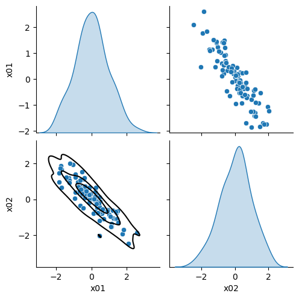

```python
g = sns.pairplot(data = xinputs_rho_neg_df, diag_kind='kde')
g.map_lower(sns.kdeplot, levels = 4, color='black')

plt.show()
```

Let's repeat the calculations for our negatively correlated inputs.

```python
X_rho_neg = dmatrix( ' ~ x01 + x02', data = xinputs_rho_neg_df)

SSmat_rho_neg = np.dot( X_rho_neg.T, X_rho_neg )

beta_cov_rho_neg = np.linalg.inv( SSmat_rho_neg )
```

The covariance matrix between the regression parameters is displayed below.

```python
print( beta_cov_rho_neg )
```

```
[[ 0.01017683 -0.00282336 -0.0029928 ]
 [-0.00282336  0.05193436  0.04550726]
 [-0.0029928   0.04550726  0.05141047]]
```

```python
print( np.sqrt( np.diag( beta_cov_rho_high) ) )
```

```
[0.10019761 0.22234347 0.21703   ]
```

Comparing these values to the two other example values, we see that the standard errors are about the same whether the inputs are highly positively correlated or highly anti-correlated! The correlation structure has made the regression coefficient slopes more uncertain!

```python
pd.DataFrame({'uncorrelated': np.sqrt( np.diag(beta_cov_rho_zero) ),
              'high positive correlation': np.sqrt( np.diag(beta_cov_rho_high)),
              'high negative correlation': np.sqrt( np.diag(beta_cov_rho_neg))},
            index=['SE beta_0', 'SE beta_1', 'SE beta_2'])
```

|  | uncorrelated | high positive correlation | high negative correlation |
| --- | --- | --- | --- |
| SE beta_0 | 0.100017 | 0.100198 | 0.100880 |
| SE beta_1 | 0.106231 | 0.222343 | 0.227891 |
| SE beta_2 | 0.109334 | 0.217030 | 0.226739 |

The correlation coefficient between $\beta_1$ and $\beta_2$ when the inputs are highly anti-correlated is:

```python
calc_cor_coef(beta_cov_rho_neg, 1, 2)
```

```
0.8806988931052256
```

Thus, when the inputs are anti-correlated the correlation coefficient between their respective slopes is highly positive!

### Monte Carlo simulation study

We practiced generating random inputs, and calculated the regression coefficient covariance, for a few values of the input correlation. However, we generated just a single random *draw* for each value of the correlation coefficient. How repeatable are our calculations? What if the inputs change slightly, we will still have the same conclusions?

To test this, we will *repeat* the simulations multiple times for each input correlation coefficient. Thus, instead of just generating 1 set of 100 input observations, we will generate 10 sets of 100 input observations. For each set, we will calculate the coefficient standard errors and the correlation coefficient between $\beta_1$ and $\beta_2$.

Also, instead of just using 3 values for the input correlation coefficient, we will try out many values for $\rho$. We will consider values of from -.99 to 0.99 in increments of 0.01.

Let's define functions to help us perform this simulation study. For simplicity we will assume there are just 2 inputs and we are using linear additive features in our model.

To allow some generality the `sim_generate_design()` function allows the user to provide non-zero means and marginal standard deviations different from one. Thus, `sim_generate_design()` works with the more general multivariate normal distribution:

$$\begin{bmatrix} x_1 \\ x_2 \end{bmatrix} \sim \mathrm{multivariate \, normal} \left( \begin{bmatrix} \mu_1 \\ \mu_2 \end{bmatrix} , \begin{bmatrix} \sigma_1^2 & \rho \sigma_1 \sigma_2 \\ \rho \sigma_1 \sigma_2 & \sigma_2^2 \end{bmatrix} \right)$$

```python
def sim_generate_design(rho, xmu, xsd, num_samples):
    xcov_val = rho * xsd[0] * xsd[1]

    xcovmat = np.array([[xsd[0], xcov_val], [xcov_val, xsd[1]]])

    xinputs = rg.multivariate_normal(xmu, xcovmat, size=num_samples)

    xdf = pd.DataFrame(xinputs, columns=['x'+str(d+1).zfill(2) for d in range(xinputs.shape[1])])

    X = dmatrix( ' ~ x01 + x02', data = xdf)

    return X
```

The `calc_lm_expressions()` function calculates the covariance matrix for the $\boldsymbol{\beta}$ parameters for a given design matrix `X`.

```python
def calc_lm_expressions(X):
    SSmat = np.dot( X.T, X )

    beta_covmat = np.linalg.inv( SSmat )

    return beta_covmat
```

The `sim_replicate()` function performs one replication of our study. It generates 1 set of a specified number of observations of the inputs, and calculates the coefficient standard errors and the correlation coefficient between $\beta_1$ and $\beta_2$. A DataFrame is returned to facilitate making figures later.

```python
def sim_replicate(rep_id, rho, xmu, xsd, N):
    Xmat = sim_generate_design(rho, xmu, xsd, N)

    bmat = calc_lm_expressions(Xmat)

    bse = np.sqrt( np.diag(bmat) )

    rho12 = calc_cor_coef(bmat, 1, 2)

    res = pd.DataFrame({'rep_id': rep_id,
                        'rho': rho,
                        'b0_se': bse[0],
                        'b1_se': bse[1],
                        'b2_se': bse[2],
                        'cor_b1_b2': rho12},
                       index=[rep_id])

    return res
```

Although we could use different values for the marginal means and standard deviations, we will continue to use marginal standard normals. Let's test out our function and confirm we get roughly the same result as we got with the highly positively correlated inputs.

```python
x_mean_vector = np.zeros(2)

x_sd_vector = np.ones(2)

sim_replicate(1, 0.9, x_mean_vector, x_sd_vector, 100)
```

|  | rep_id | rho | b0_se | b1_se | b2_se | cor_b1_b2 |
| --- | --- | --- | --- | --- | --- | --- |
| 1 | 1 | 0.9 | 0.100263 | 0.23319 | 0.239699 | -0.891723 |

We will use a simple nested for-loop to loop over the desired values for the correlation coefficient and the desired number of replications for each value of $\rho$. We will create a NumPy 1D array between -0.99 to 0.99 in increments (step size) of 0.01 with the `np.arange()` function. The number of replications are created simply with `range(10)` since we want to use 10 replications for each correlation coefficient.

```python
rho_use = np.arange(-0.99, 1.0, 0.01) #np.arange() stop is exclusive...

reps_use = range(10)

res_list = []

for rho_v in rho_use:
    for rid in reps_use:
        res_list.append( sim_replicate(rid, rho_v, x_mean_vector, x_sd_vector, 100))
```

We can now compile all results into a single DataFrame.

```python
sim_study_df = pd.concat( res_list )
```

```python
sim_study_df
```

|  | rep_id | rho | b0_se | b1_se | b2_se | cor_b1_b2 |
| --- | --- | --- | --- | --- | --- | --- |
| 0 | 0 | -0.99 | 0.100690 | 0.748234 | 0.741721 | 0.988439 |
| 1 | 1 | -0.99 | 0.100347 | 0.655948 | 0.649782 | 0.987980 |
| 2 | 2 | -0.99 | 0.100147 | 0.686681 | 0.671980 | 0.987699 |
| 3 | 3 | -0.99 | 0.100455 | 0.667898 | 0.660315 | 0.987499 |
| 4 | 4 | -0.99 | 0.100010 | 0.817782 | 0.814488 | 0.989604 |
| ... | ... | ... | ... | ... | ... | ... |
| 5 | 5 | 0.99 | 0.100252 | 0.733890 | 0.744268 | -0.993756 |
| 6 | 6 | 0.99 | 0.101084 | 0.732284 | 0.740341 | -0.989786 |
| 7 | 7 | 0.99 | 0.100174 | 0.750061 | 0.746014 | -0.990491 |
| 8 | 8 | 0.99 | 0.100504 | 0.807915 | 0.819624 | -0.993281 |
| 9 | 9 | 0.99 | 0.100498 | 0.817731 | 0.815128 | -0.994314 |

1990 rows × 6 columns

Let's use Seaborn to study the variation on the correlation coefficient between $\beta_1$ and $\beta_2$ as we change the value of $\rho$. To show the $\pm$ 1 standard deviation around the average instead of the confidence interval on the average, we must set `errorbar` equal to `'sd'`. The result shows that the correlation coefficient between $\beta_1$ and $\beta_2$ is linear with respect to the input $\rho$! Our line looks a little choppy, but if we would use more replications for example 50 or 100, that "choppyness" would go away.

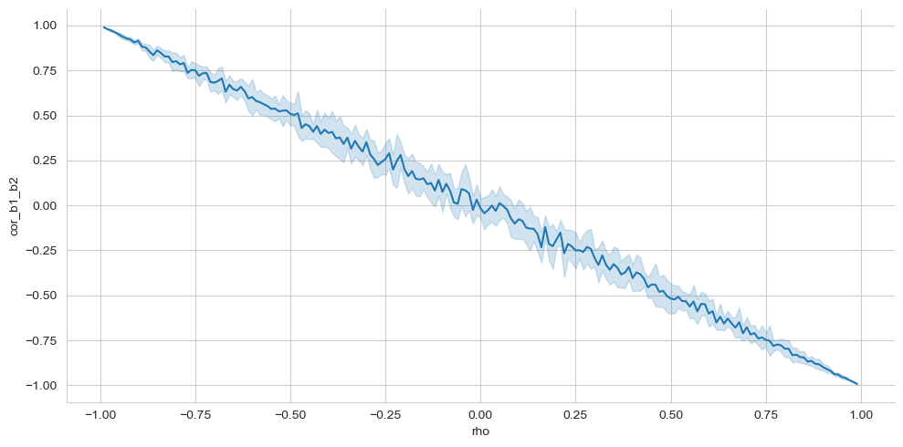

```python
sns.set_style('whitegrid')

sns.relplot(data = sim_study_df, x='rho', y='cor_b1_b2', kind='line', errorbar='sd', aspect=2)

plt.show()
```

Finally, let's examine the *scaled* standard error on the regression coefficients. We will first melt the DataFrame into a long-format so we can focus on the slopes $\beta_1$ and $\beta_2$.

```python
sim_study_slope_se = sim_study_df.loc[:, ['rep_id', 'rho', 'b1_se', 'b2_se']].copy().\
melt(id_vars=['rep_id', 'rho'], value_vars=['b1_se', 'b2_se'])
```

```python
sim_study_slope_se
```

|  | rep_id | rho | variable | value |
| --- | --- | --- | --- | --- |
| 0 | 0 | -0.99 | b1_se | 0.748234 |
| 1 | 1 | -0.99 | b1_se | 0.655948 |
| 2 | 2 | -0.99 | b1_se | 0.686681 |
| 3 | 3 | -0.99 | b1_se | 0.667898 |
| 4 | 4 | -0.99 | b1_se | 0.817782 |
| ... | ... | ... | ... | ... |
| 3975 | 5 | 0.99 | b2_se | 0.744268 |
| 3976 | 6 | 0.99 | b2_se | 0.740341 |
| 3977 | 7 | 0.99 | b2_se | 0.746014 |
| 3978 | 8 | 0.99 | b2_se | 0.819624 |
| 3979 | 9 | 0.99 | b2_se | 0.815128 |

3980 rows × 4 columns

Let's now use Seaborn to visualize the average and $\pm$ 1 standard deviation interval around the average (so not the confidence interval on the average) for the standard errors with respect to the input correlation coefficient.

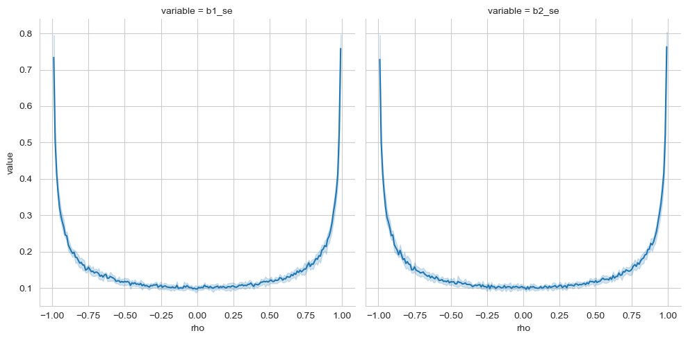

```python
sns.relplot(data = sim_study_slope_se, x='rho', y='value', kind='line', errorbar='sd', col='variable')

plt.show()
```

When the input correlation is relatively low, $-0.5 < \rho < 0.5$, the standard error on the coefficients is roughly the same value as if the inputs were uncorrelated, $\rho=0$. However, the standard errors start to increase for $0.5 < |\rho| < 0.85$. Then, the standard errors increase essentially exponentially when $|\rho| > 0.85$.

This is why the usual recommendation is that if your inputs are correlated with correlation coefficients of greater than 0.85 or less than -0.85 model interpretation will be impacted! The regression coefficients will be correlated which raises the uncertainty on the regression coefficients!

## Summary

This notebook involved more math than most examples this semester. The primary point is that we used random number generators to demonstrate an important concept about model behavior. Randomly generating data can therefore help us understand how models work!